# Dynamic Landmarking on SPLC Data

Anya Fries

17/01/2022

## Data loading and preparation

*Note: hist_final is one-hot encoded, with SC used as a reference, in order to allow for the operation: coefficient $\times$ LM*

#### Load data and libraries

```r
library(tidyverse)
library(cowplot)
library(survival)
library(dynpred)
library(riskRegression)
library(msm) # for delta method
library(knitr) # for kable to print tables

source("Anya SPLC-RAT Dev Data/source_general.R")
source("dyn-landmarking.R")
source("SPLC-helper-functions.R")

MYDAT <- read.csv("Anya SPLC-RAT Dev Data/DAT_splcrat.csv")
MYDAT <- MYDAT[MYDAT$Time>0,]
```

#### Set up base data with relevant covariates

```r
covars <- c("ID_secLung","stage2.ix","hist_final","ph","USPSTF2","cigday2","surgery1")

add_vars <- c("packyears2",  "smkstatus2", "quityears2","age_ix",
              "packyears_fup","smkstatus_fup","cigday_fup",
              "diff_fup_IPLC") # Time from FUP to IPLC
all_vars <- c(covars,add_vars)

MEC <- MYDAT %>%
  select(Time,event,all_of(all_vars)) %>%
  mutate(USPSTF.stage = USPSTF2 * stage2.ix,
         value = 1)  %>%
  spread(hist_final, value,  fill = 0 ) %>%
  select(-SC) # one-hot encodings of hist_final

hist_final_labels <- c("AD","LC","NSCLC_NOS","OTH","SQ")
covars <- c(covars[-3], "USPSTF.stage", hist_final_labels)
all_vars <- c(covars,add_vars)

 # reorder to have add_vars at the end
MEC <- MEC %>% select(Time,event,ID_secLung:surgery1,USPSTF.stage:SQ,all_of(add_vars))
colnames(MEC)
```

```
##  [1] "Time"          "event"         "ID_secLung"    "stage2.ix"
##  [5] "ph"            "USPSTF2"       "cigday2"       "surgery1"
##  [9] "USPSTF.stage"  "AD"            "LC"            "NSCLC_NOS"
## [13] "OTH"           "SQ"            "packyears2"    "smkstatus2"
## [17] "quityears2"    "age_ix"        "packyears_fup" "smkstatus_fup"
## [21] "cigday_fup"    "diff_fup_IPLC"
```

## Create landmarking super data set

We set our specific values and build the super LM dataset. We will produce 5-year dynamic predictions of SPLC. Landmark time points were established every 6 months between 0 and 3 years.

```r
w <- 5        # risk prediction window (risk within time w)

LMs <- seq(0,3,by=0.5)
outcome <- list(time="Time",status="event")
covs <- list(fixed=all_vars,varying=NULL)

# f gives covariate-time interactions
f1 <- function(t) 1
f2 <- function(t) t
f3 <- function(t) t^2

# g lets the hazard depend on time
g1 <- function(t) f2(t)
g2 <- function(t) f3(t)

func_covars <- list(c(f1,f2,f3))
func_LMs <- list(c(g1,g2))

# Choose variables that will have time interaction
pred_covars <- covars[2:length(covars)]
```

```r
# Stack datasets
LMdata <- cutLMsuper(MEC, outcome, LMs, w, covs, format="wide")
# Update LM-varying covariates (user created function update)
LMdata <- update(LMdata)
# Add time interactions
LMdata <- addLMtime(LMdata, pred_covars, func_covars, func_LMs)

str(LMdata)
```

```
## List of 7
##  $ LMdata     :'data.frame': 16938 obs. of  47 variables:
##   ..$ Time          : num [1:16938] 0.1671 0.0849 1.5068 3.7507 5 ...
##   ..$ event         : num [1:16938] 2 2 2 0 0 3 0 2 2 2 ...
##   ..$ ID_secLung    : chr [1:16938] "MSL0002" "MSL0004" "MSL0005" "MSL0006" ...
##   ..$ packyears2    : num [1:16938] 32.5 NA 31.8 19.8 45.3 19.8 45.3 19.8 16.4 52.3 ...
##   ..$ smkstatus2    : int [1:16938] 2 2 2 2 2 3 3 3 3 3 ...
##   ..$ quityears2    : num [1:16938] 18 21 0.5 13 18 NA NA NA NA NA ...
##   ..$ age_ix        : num [1:16938] 79 89.4 76.8 75.5 80.2 ...
##   ..$ packyears_fup : num [1:16938] 32.5 NA NA NA NA NA NA NA NA NA ...
##   ..$ smkstatus_fup : int [1:16938] 2 NA NA NA NA NA NA NA NA NA ...
##   ..$ cigday_fup    : num [1:16938] 15.5 NA NA NA NA NA NA NA NA NA ...
##   ..$ diff_fup_IPLC : num [1:16938] 6.51 NA NA NA NA ...
##   ..$ LM            : num [1:16938] 0 0 0 0 0 0 0 0 0 0 ...
##   ..$ stage2.ix_1   : num [1:16938] 1 1 1 1 0 0 0 1 0 1 ...
##   ..$ stage2.ix_2   : num [1:16938] 0 0 0 0 0 0 0 0 0 0 ...
##   ..$ stage2.ix_3   : num [1:16938] 0 0 0 0 0 0 0 0 0 0 ...
##   ..$ ph_1          : num [1:16938] 1 0 1 0 1 0 1 0 0 0 ...
##   ..$ ph_2          : num [1:16938] 0 0 0 0 0 0 0 0 0 0 ...
##   ..$ ph_3          : num [1:16938] 0 0 0 0 0 0 0 0 0 0 ...
##   ..$ USPSTF2_1     : num [1:16938] 0 0 1 0 0 0 0 0 0 1 ...
##   ..$ USPSTF2_2     : num [1:16938] 0 0 0 0 0 0 0 0 0 0 ...
##   ..$ USPSTF2_3     : num [1:16938] 0 0 0 0 0 0 0 0 0 0 ...
##   ..$ cigday2_1     : num [1:16938] 15.5 5 15.5 15.5 25.5 15.5 25.5 15.5 8 25.5 ...
##   ..$ cigday2_2     : num [1:16938] 0 0 0 0 0 0 0 0 0 0 ...
##   ..$ cigday2_3     : num [1:16938] 0 0 0 0 0 0 0 0 0 0 ...
##   ..$ surgery1_1    : num [1:16938] 0 0 0 1 1 0 0 1 1 0 ...
##   ..$ surgery1_2    : num [1:16938] 0 0 0 0 0 0 0 0 0 0 ...
##   ..$ surgery1_3    : num [1:16938] 0 0 0 0 0 0 0 0 0 0 ...
##   ..$ USPSTF.stage_1: num [1:16938] 0 0 1 0 0 0 0 0 0 1 ...
##   ..$ USPSTF.stage_2: num [1:16938] 0 0 0 0 0 0 0 0 0 0 ...
##   ..$ USPSTF.stage_3: num [1:16938] 0 0 0 0 0 0 0 0 0 0 ...
##   ..$ AD_1          : num [1:16938] 1 0 0 1 0 0 0 1 0 1 ...
##   ..$ AD_2          : num [1:16938] 0 0 0 0 0 0 0 0 0 0 ...
##   ..$ AD_3          : num [1:16938] 0 0 0 0 0 0 0 0 0 0 ...
##   ..$ LC_1          : num [1:16938] 0 0 1 0 0 0 0 0 0 0 ...
##   ..$ LC_2          : num [1:16938] 0 0 0 0 0 0 0 0 0 0 ...
##   ..$ LC_3          : num [1:16938] 0 0 0 0 0 0 0 0 0 0 ...
##   ..$ NSCLC_NOS_1   : num [1:16938] 0 1 0 0 0 0 0 0 0 0 ...
##   ..$ NSCLC_NOS_2   : num [1:16938] 0 0 0 0 0 0 0 0 0 0 ...
```

[output cut: 20 more lines]

[output not shown]

## Build the predictive model

Fit the supermodel using all of the covariates on the super dataset. Note that `LMdata$allLMcovars` gives all the covariates with LM interaction (`LMdata$LMcovars` are these same covariates but without interaction). A subset of these variables can be used.

```r
model_covars <- LMdata$allLMcovars
print(model_covars)
```

```
##  [1] "stage2.ix_1"    "stage2.ix_2"    "stage2.ix_3"    "ph_1"
##  [5] "ph_2"           "ph_3"           "USPSTF2_1"      "USPSTF2_2"
##  [9] "USPSTF2_3"      "cigday2_1"      "cigday2_2"      "cigday2_3"
## [13] "surgery1_1"     "surgery1_2"     "surgery1_3"     "USPSTF.stage_1"
## [17] "USPSTF.stage_2" "USPSTF.stage_3" "AD_1"           "AD_2"
## [21] "AD_3"           "LC_1"           "LC_2"           "LC_3"
## [25] "NSCLC_NOS_1"    "NSCLC_NOS_2"    "NSCLC_NOS_3"    "OTH_1"
## [29] "OTH_2"          "OTH_3"          "SQ_1"           "SQ_2"
## [33] "SQ_3"           "LM_1"           "LM_2"
```

```r
source("dyn-landmarking.R")
source("SPLC-helper-functions.R")
formula <- paste("Hist(Time, event, LM)", "~",
                 paste(model_covars, collapse=" + "), "+ cluster(ID_secLung)")
LMsupercsc2 <- fitLM("CSC", as.formula(formula), LMdata, cause=1, method="breslow")
# LMsupercsc2
```

## Exploring the predictive model

### Exploring the coefficients of the model

```r
library(htmlTable)
n_dec <- 2
get_coef_info(LMsupercsc2$superfm, n_dec, CI=FALSE, pVal=TRUE)
```

|  | Cause 1: SPLC HR.1 | Cause 1: SPLC p.value.1 |  | Cause 2: IPLC death HR.2 | Cause 2: IPLC death p.value.2 |  | Cause 3: Other-cause death HR.3 | Cause 3: Other-cause death p.value.3 |
| --- | --- | --- | --- | --- | --- | --- | --- | --- |
| AD_1 | 2.37 | 0.43 |  | 0.86 | 0.01 |  | 1.19 | 0.3 |
| AD_2 | 0.28 | 0.13 |  | 0.63 | 0 |  | 0.97 | 0.93 |
| AD_3 | 1.19 | 0.31 |  | 1.39 | 0 |  | 0.98 | 0.82 |
| cigday2_1 | 1.01 | 0.62 |  | 1 | 0.37 |  | 1 | 0.62 |
| cigday2_2 | 0.99 | 0.69 |  | 0.99 | 0.11 |  | 1 | 0.94 |
| cigday2_3 | 1 | 0.5 |  | 1 | 0.13 |  | 1 | 0.65 |
| LC_1 | 8.17 | 0.06 |  | 1.24 | 0.07 |  | 2 | 0.01 |
| LC_2 | 0.79 | 0.77 |  | 0.68 | 0.15 |  | 0.65 | 0.41 |
| LC_3 | 0.78 | 0.17 |  | 1.16 | 0.28 |  | 1.09 | 0.58 |
| LM_1 | 3.18 | 0.21 |  | 2.34 | 0 |  | 1.02 | 0.94 |
| LM_2 | 0.89 | 0.55 |  | 0.66 | 0 |  | 0.99 | 0.95 |
| NSCLC_NOS_1 | 1.69 | 0.68 |  | 1.1 | 0.19 |  | 1.49 | 0.04 |
| NSCLC_NOS_2 | 0.22 | 0.18 |  | 0.78 | 0.15 |  | 1.01 | 0.98 |
| NSCLC_NOS_3 | 1.36 | 0.23 |  | 1.28 | 0.01 |  | 0.93 | 0.57 |
| OTH_1 | 2.77 | 0.38 |  | 1.04 | 0.6 |  | 1.72 | 0 |
| OTH_2 | 0.24 | 0.19 |  | 0.46 | 0 |  | 0.64 | 0.22 |
| OTH_3 | 1.04 | 0.92 |  | 1.51 | 0 |  | 1.07 | 0.54 |
| ph_1 | 1.7 | 0.03 |  | 0.94 | 0.15 |  | 1.3 | 0 |
| ph_2 | 1.33 | 0.14 |  | 1.12 | 0.16 |  | 1.2 | 0.15 |
| ph_3 | 0.86 | 0.01 |  | 0.94 | 0.03 |  | 0.96 | 0.35 |
| SQ_1 | 2.97 | 0.33 |  | 0.92 | 0.18 |  | 1.34 | 0.08 |
| SQ_2 | 0.39 | 0.25 |  | 0.59 | 0 |  | 0.98 | 0.95 |
| SQ_3 | 1.1 | 0.58 |  | 1.37 | 0 |  | 0.99 | 0.95 |
| stage2.ix_1 | 0.6 | 0.34 |  | 1.99 | 0 |  | 1.28 | 0.02 |
| stage2.ix_2 | 2.88 | 0.04 |  | 0.49 | 0 |  | 0.64 | 0.02 |
| stage2.ix_3 | 0.51 | 0 |  | 1.2 | 0 |  | 1.14 | 0.05 |
| surgery1_1 | 2.32 | 0.02 |  | 0.34 | 0 |  | 0.51 | 0 |
| surgery1_2 | 0.98 | 0.96 |  | 1.12 | 0.15 |  | 1.34 | 0.03 |
| surgery1_3 | 1.06 | 0.54 |  | 1 | 0.98 |  | 0.98 | 0.65 |
| USPSTF.stage_1 | 0.41 | 0.31 |  | 1.12 | 0.16 |  | 0.93 | 0.69 |
| USPSTF.stage_2 | 0.68 | 0.45 |  | 1.37 | 0.04 |  | 0.48 | 0.04 |
| USPSTF.stage_3 | 1.87 | 0 |  | 0.87 | 0.04 |  | 1.27 | 0.04 |
| USPSTF2_1 | 2.65 | 0 |  | 1.07 | 0.31 |  | 0.94 | 0.67 |
| USPSTF2_2 | 1.01 | 0.98 |  | 1.11 | 0.3 |  | 1.21 | 0.22 |
| USPSTF2_3 | 0.86 | 0.11 |  | 0.96 | 0.35 |  | 0.96 | 0.5 |

### Visualising the changing hazard ratios for different covariates

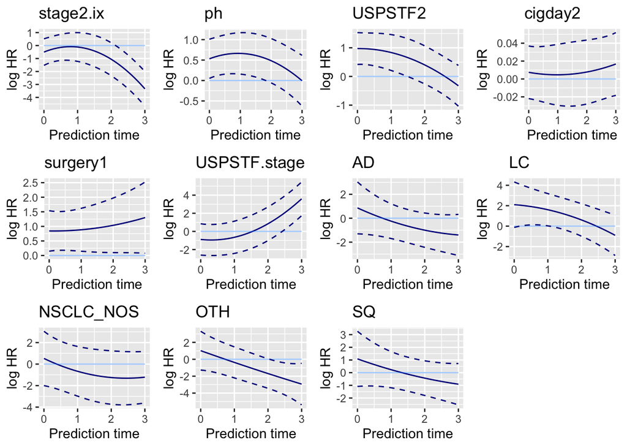

```r
plot_dynamic_HR(LMsupercsc2, end_time=3, CI=TRUE)
```

## Prediction

A prediction is made for an individual at a specific prediction time (e.g., at baseline, at 2 years, etc). Thus both an individual and a prediction (landmark) time must be given. The $w$-year risk is predicted ($w$ is set when fitting the model).

### Create newdata

New data is a dataframe with individual covariates associated with a LMing time point (i.e. covariates updated for the LMing time-point). Only the covariates used in the model need to be provided. E.g., this can be an entry from the very original data frame. Note that cutLM/cutLMsuper can be used to create these individuals for later prediction time points.

New data can be entire dataframes associated with one LM-time, for e.g., as follows:

```r
times1 <- c(0,1,2)

# update time varying covariates for each of these prediction points
# use a custom function cutLMnewdata which is the same at cutLM but without censoring time at prediction window
newdata1 <- lapply(times1,
                  function(t){
                    update(cutLMnewdata(MEC, outcome, t, t+w, covs, format="wide"))
                    }
                  )

print("Data on which to perform 5-year risk prediction at 1 year:")
```

```
## [1] "Data on which to perform 5-year risk prediction at 1 year:"
```

```r
head(newdata1[[2]])
```

```
##        Time event ID_secLung stage2.ix ph USPSTF2 cigday2 surgery1 USPSTF.stage
## 3  1.506849     2    MSL0005         1  1       1    15.5        0            1
## 4  3.750685     0    MSL0006         1  0       0    15.5        1            0
## 5 10.342466     0    MSL0007         0  1       0    25.5        1            0
## 6  1.331507     3    MSL0008         0  0       0    15.5        0            0
## 7  6.172603     0    MSL0009         0  1       0    25.5        0            0
## 8  2.747945     2    MSL0011         1  0       0    15.5        1            0
##   AD LC NSCLC_NOS OTH SQ packyears2 smkstatus2 quityears2   age_ix
## 3  0  1         0   0  0     31.800          2        1.5 77.80000
## 4  1  0         0   0  0     19.800          2       14.0 76.47123
## 5  0  0         0   0  1     45.300          2       19.0 81.21644
## 6  0  0         0   0  1     20.575          3         NA 69.29863
## 7  0  0         0   0  1     46.575          3         NA 88.55616
## 8  1  0         0   0  0     20.575          3         NA 53.45205
##   packyears_fup smkstatus_fup cigday_fup diff_fup_IPLC LM
## 3            NA            NA         NA            NA  1
## 4            NA            NA         NA            NA  1
## 5            NA            NA         NA            NA  1
## 6            NA            NA         NA            NA  1
## 7            NA            NA         NA            NA  1
## 8            NA            NA         NA            NA  1
```

New data can be whole dataframes associated with multiple times, where one LM/prediction time is given for each row. Here we also make predictions at 0,1,2 years but store all the data together.

```r
option2 <- cutLMsuper(MEC, outcome, times1, w, covs, "wide")
newdata2 <- option2$LMdata
times2 <- newdata2$LM

head(newdata2)
```

```
##         Time event ID_secLung stage2.ix ph USPSTF2 cigday2 surgery1
## 1 0.16712329     2    MSL0002         1  1       0    15.5        0
## 2 0.08493151     2    MSL0004         1  0       0     5.0        0
## 3 1.50684932     2    MSL0005         1  1       1    15.5        0
## 4 3.75068493     0    MSL0006         1  0       0    15.5        1
## 5 5.00000000     0    MSL0007         0  1       0    25.5        1
## 6 1.33150685     3    MSL0008         0  0       0    15.5        0
##   USPSTF.stage AD LC NSCLC_NOS OTH SQ packyears2 smkstatus2 quityears2   age_ix
## 1            0  1  0         0   0  0       32.5          2       18.0 78.97260
## 2            0  0  0         1   0  0         NA          2       21.0 89.39726
## 3            1  0  1         0   0  0       31.8          2        0.5 76.80000
## 4            0  1  0         0   0  0       19.8          2       13.0 75.47123
## 5            0  0  0         0   0  1       45.3          2       18.0 80.21644
## 6            0  0  0         0   0  1       19.8          3         NA 68.29863
##   packyears_fup smkstatus_fup cigday_fup diff_fup_IPLC LM
## 1          32.5             2       15.5      6.506849  0
## 2            NA            NA         NA            NA  0
## 3            NA            NA         NA            NA  0
## 4            NA            NA         NA            NA  0
## 5            NA            NA         NA            NA  0
## 6            NA            NA         NA            NA  0
```

```r
head(times2)
```

```
## [1] 0 0 0 0 0 0
```

#### Get predictions for each individual

Predictions can be made on either form:

```r
risks1 <- list()

for (t in 1:length(times1)){
  tLM <- times1[t]
  newdat <- newdata1[[t]][,]

  risks <- predLMrisk(LMsupercsc2, newdat, tLM, cause=1)
  risks1[[t]] <- risks
}
```

```r
risks2 <- predLMrisk(LMsupercsc2, newdata2, times2, cause=1)
```

### Calibration: quantile-based calibration plot

This function builds on `calPlot` from the `pec` library. The object from `predLMrisk` already stores the time at which the prediction was made and the prediction window, so these do not need to be input. A named list of prediction objects from `predLMrisk` allows for comparison between models.

```r
library(pec)
```

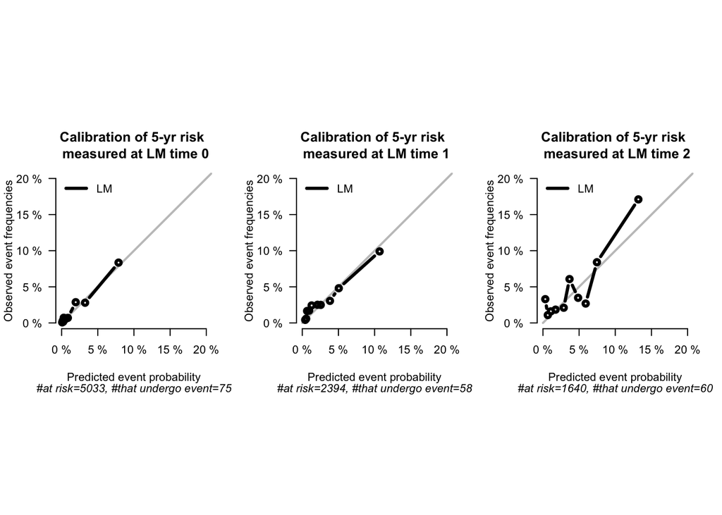

```r
source("dyn-landmarking.R")
method="quantile"
q=10
YLIM=XLIM=c(0,0.2)

# risks2 <- risks1
# risks2$preds$risk = risks2$preds$risk + 0.03

par(mfrow=c(1,3),pty="s")
outlist = LMcalPlot(list("LM"=risks2), cause=1, method=method, q=q ,ylim=YLIM, xlim=XLIM) #,"LM2"=risks2
```

### AUCt and Brier Score

Similarly, time-dependent AUC and Brier Score can be computed.

Extract in a data frame:

```r
library(data.table)
```

```r
l2 = LMScore(list("LM1"=risks2), cause=1)
print(l2)
```

```
##
## Metric: Time-dependent AUC for 5-year risk prediction
##
## Results by model:
##    tLM model times    AUC  lower  upper
## 1:   0   LM1     5 89.028 86.230 91.826
## 2:   1   LM1     6 79.393 75.820 82.966
## 3:   2   LM1     7 76.058 72.507 79.610
##
## Results by comparison:
## TODO
```

```
##
## NOTE: Values are multiplied by 100 and given in %.
```

```
## NOTE: The higher AUC the better.
```

```
## NOTE: Predictions are made at time tLM for 5-year risk
```

```
##
## Metric: Brier Score for 5-year risk prediction
##
## Results by model:
##    tLM      model times Brier lower upper
## 1:   0 Null model     5 1.650 1.282 2.019
## 2:   0        LM1     5 1.526 1.189 1.864
## 3:   1 Null model     6 2.807 2.099 3.514
## 4:   1        LM1     6 2.598 1.944 3.252
## 5:   2 Null model     7 4.342 3.274 5.410
## 6:   2        LM1     7 4.049 3.047 5.051
##
## Results by comparison:
## TODO
```

```
##
## NOTE: Values are multiplied by 100 and given in %.
```

```
## NOTE: The lower Brier the better.
```

```
## NOTE: Predictions are made at time tLM for 5-year risk
```

### Individual risk score trajectories

Individual risk score trajectories can be plotted. As with `predLMrisk`, the data input is in the form of the original data. For example:

```r
idx <- c(5, 383, 880, 1044)
kable(MEC[idx,])
```

|  | Time | event | ID_secLung | stage2.ix | ph | USPSTF2 | cigday2 | surgery1 | USPSTF.stage | AD | LC | NSCLC_NOS | OTH | SQ | packyears2 | smkstatus2 | quityears2 | age_ix | packyears_fup | smkstatus_fup | cigday_fup | diff_fup_IPLC |
| --- | --- | --- | --- | --- | --- | --- | --- | --- | --- | --- | --- | --- | --- | --- | --- | --- | --- | --- | --- | --- | --- | --- |
| 5 | 10.342466 | 0 | MSL0007 | 0 | 1 | 0 | 25.5 | 1 | 0 | 0 | 0 | 0 | 0 | 1 | 45.3 | 2 | 18 | 80.21644 | NA | NA | NA | NA |
| 383 | 8.416438 | 2 | MSL0535 | 0 | 1 | 0 | 8.0 | 1 | 0 | 0 | 0 | 0 | 1 | 0 | 2.0 | 3 | NA | 71.46849 | 17.9 | 2 | 15.5 | -4.164384 |
| 880 | 15.758904 | 0 | MSL1253 | 0 | 0 | 1 | 15.5 | 1 | 0 | 1 | 0 | 0 | 0 | 0 | 31.8 | 3 | NA | 77.30411 | 39.5 | 2 | 15.5 | -2.167123 |
| 1044 | 8.509589 | 2 | MSL1488 | 0 | 0 | 1 | 25.5 | 1 | 0 | 1 | 0 | 0 | 0 | 0 | 52.3 | 3 | NA | 74.13425 | 60.0 | 2 | 15.5 | -1.167123 |

We turn our data into long-form data to plot: (wide-form can be used too)

```r
# Prediction time points
x = seq(0,9,by=0.02)

# Create long-form data to plot individual trajetory
dat = cutLMsuper(MEC[idx,],outcome, x, w, covs, format="wide")
dat = update(dat)

head(dat$LMdata)
```

```
##      Time event ID_secLung stage2.ix ph USPSTF2 cigday2 surgery1 USPSTF.stage
## 5    5.00     0    MSL0007         0  1       0    25.5        1            0
## 383  5.00     0    MSL0535         0  1       0     8.0        1            0
## 880  5.00     0    MSL1253         0  0       1    15.5        1            0
## 1044 5.00     0    MSL1488         0  0       1    25.5        1            0
## 51   5.02     0    MSL0007         0  1       0    25.5        1            0
## 3831 5.02     0    MSL0535         0  1       0     8.0        1            0
##      AD LC NSCLC_NOS OTH SQ packyears2 smkstatus2 quityears2   age_ix
## 5     0  0         0   0  1     45.300          2      18.00 80.21644
## 383   0  0         0   1  0      2.000          3         NA 71.46849
## 880   1  0         0   0  0     31.800          3         NA 77.30411
## 1044  1  0         0   0  0     52.300          3         NA 74.13425
## 51    0  0         0   0  1     45.300          2      18.02 80.23644
## 3831  0  0         0   1  0      2.008          3         NA 71.48849
##      packyears_fup smkstatus_fup cigday_fup diff_fup_IPLC   LM
## 5               NA            NA         NA            NA 0.00
## 383           17.9             2       15.5     -4.164384 0.00
## 880           39.5             2       15.5     -2.167123 0.00
## 1044          60.0             2       15.5     -1.167123 0.00
## 51              NA            NA         NA            NA 0.02
## 3831          17.9             2       15.5     -4.164384 0.02
```

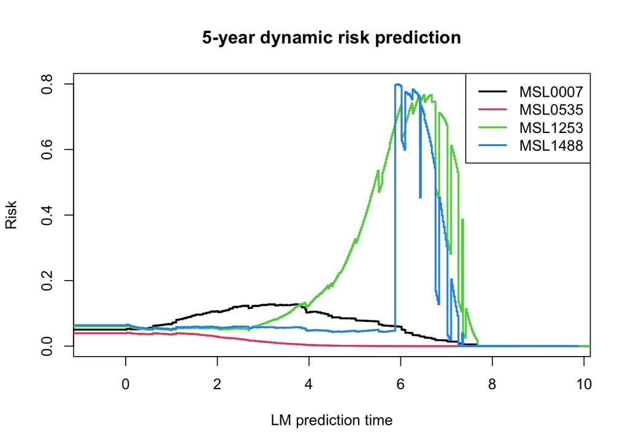

```r
plotRisk(LMsupercsc2, dat$LMdata,
            format="long", LM_col = "LM", id_col="ID_secLung", cause=1,ylim=c(0,0.8))
```